# Reproducible Research: Peer Assessment 1

Setting echo=TRUE so that we are able to view the code chunks

```r
knitr::opts_chunk$set(echo = TRUE)
```

## Loading and preprocessing the data

Reading the data and formatting the date column as Date.

```r
setwd('C:/Users/320089162/Downloads/RepData_PeerAssessment1-master/RepData_PeerAssessment1-master/activity')
data=read.csv('activity.csv', stringsAsFactors = FALSE)
data$date=as.Date(data$date)
```

## What is mean total number of steps taken per day?

Ignoring the missing values for now. Then, plotting a histogram of the total number of steps taken per day.

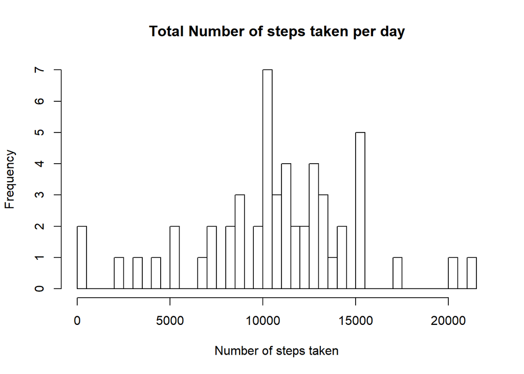

```r
data_ignoring_nas=data[!is.na(data$steps),]
totalsteps=aggregate(steps~date,FUN=sum,data=data_ignoring_nas)
hist(totalsteps$steps,breaks = 50,xlab = "Number of steps taken", main = "Total Number of steps taken per day")
```

Finally, finding the mean and median of total steps taken per day.

```r
mean(totalsteps$steps)
```

```
## [1] 10766.19
```

```r
median(totalsteps$steps)
```

```
## [1] 10765
```

## What is the average daily activity pattern?

Plotting the average steps taken averaged over all days in each 5-minute interval.

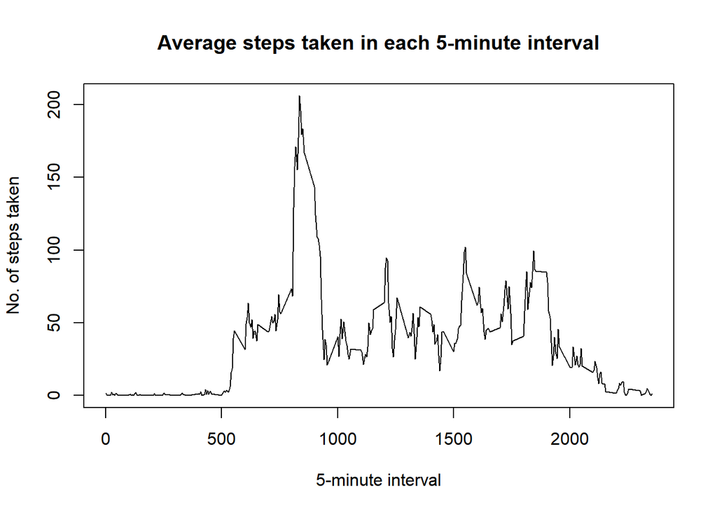

```r
meanstep=aggregate(steps~interval,data=data_ignoring_nas,mean)
plot(meanstep$interval,meanstep$steps,type='l', xlab = "5-minute interval", ylab = "No. of steps taken", main= "Average steps taken in each 5-minute interval")
```

Displaying the 5-minute interval when the maximum steps were taken.

```r
meanstep[which(meanstep$steps==max(meanstep$steps)),]$interval
```

```
## [1] 835
```

## Imputing missing values

Displaying number of records having missing values.

```r
sum(is.na(data))
```

```
## [1] 2304
```

```r
newdata=data
for (i in 1:17568)
{
     if(is.na(data[i, 1])==TRUE)
       {
        data[i, 1] <- meanstep[meanstep$interval %in% data[i,3], 2]
    }
}
```

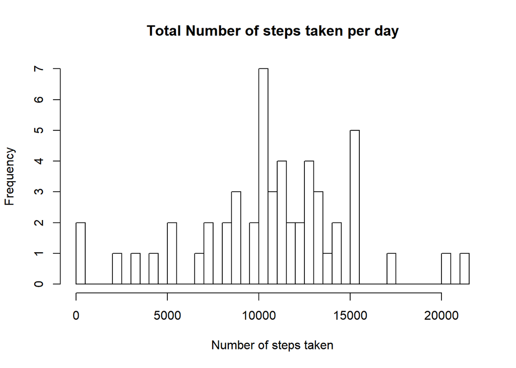

```r
totalsteps=aggregate(steps~date,FUN=sum,data=newdata)
hist(totalsteps$steps,breaks = 50,xlab = "Number of steps taken", main = "Total Number of steps taken per day")
```

```r
mean(totalsteps$steps)
```

```
## [1] 10766.19
```

```r
median(totalsteps$steps)
```

```
## [1] 10765
```

## Are there differences in activity patterns between weekdays and weekends?

We create a new variable which tells us whether the day on a particular date was a weekday or a weekend. We make this new variable a factor, which has only 2 levels- weekday and weekend.

```r
for(i in 1:17568)
{
if(weekdays(newdata$date[i])=="Saturday"| weekdays(newdata$date[i])=="Sunday")
{
  newdata$factor[i]='weekend'
}
else
{
   newdata$factor[i]='weekday'
}
}
newdata$factor=as.factor(newdata$factor)
```

Finally, we plot the average of steps taken in a particular 5-minute interval on weekdays and weekends separtely.

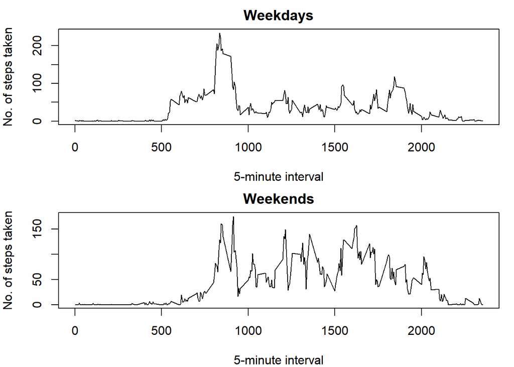

```r
weekdata=newdata[which(newdata$factor=='weekday'),]
weekenddata=newdata[which(newdata$factor=='weekend'),]
meanweekstep=aggregate(steps~interval,data=weekdata,mean)
meanweekendstep=aggregate(steps~interval,data=weekenddata,mean)
par(mfrow=c(2, 1), mar=c(4,4,2,1))
plot(meanweekstep$interval,meanweekstep$steps,type='l',xlab = "5-minute interval", ylab = "No. of steps taken", main= "Weekdays")
plot(meanweekendstep$interval,meanweekendstep$steps,type='l',xlab = "5-minute interval", ylab = "No. of steps taken", main= "Weekends")
```